# CMS Similar Physicians Data Exploratory Analysis

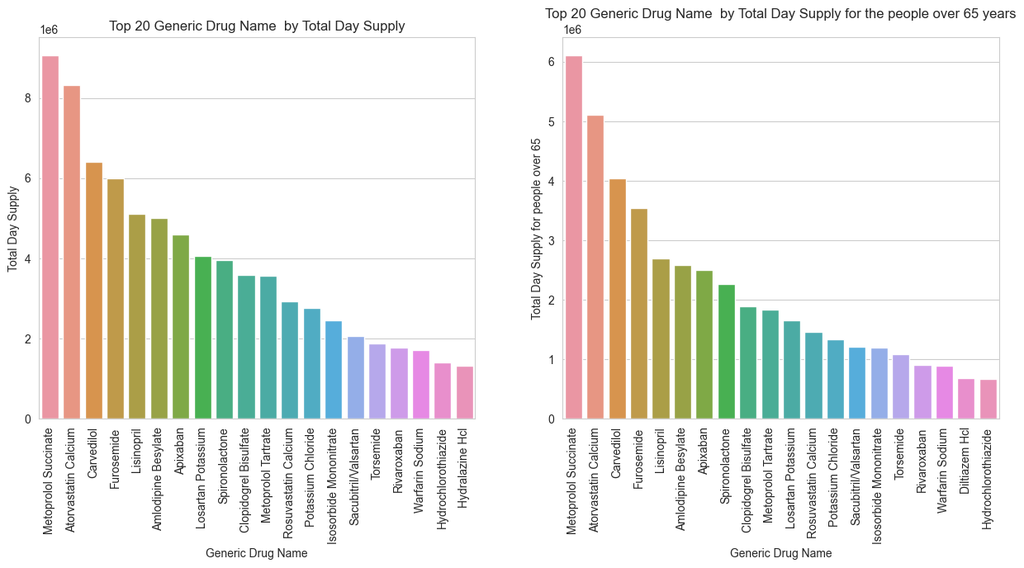

this chart is showing the top 20 generic Drug Name by the Total day supply , we have two charts one for normal people and the other one for people over 65 years . we can find that the first four drugs are the same in both charts but normal people have much higher frequencies.

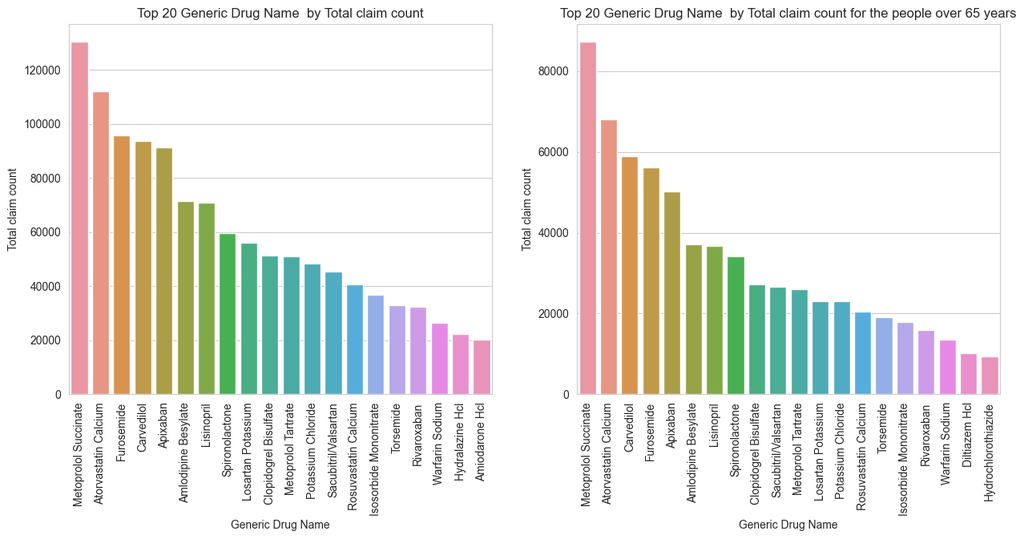

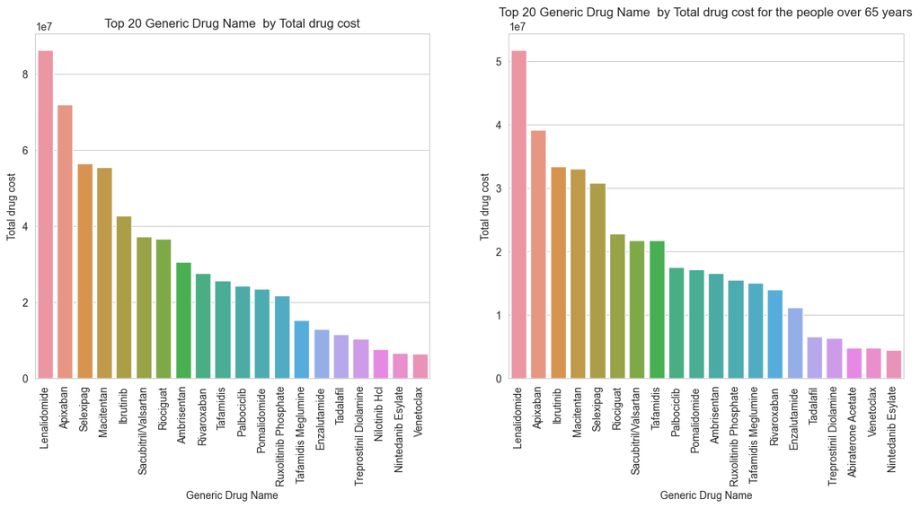

this chart is showing the top 20 generic Drug Name by the Total drug cost , we have two charts one for normal people and the other one for people over 65 years .

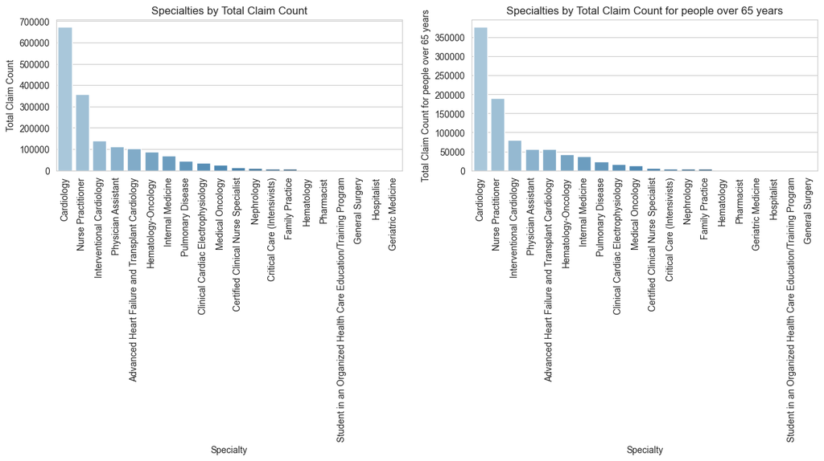

this chart is showing the relationship between the speciality and total claim count ,

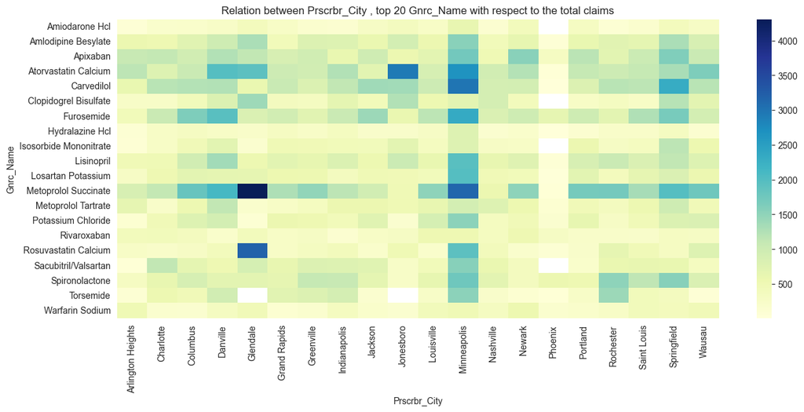

In this chart we got the top 20 generic drug names in total claims and then we are showing the relation of this drugs to each city. we can gain insight about the cities that need specific drugs more than the others through our heatmap , the heat bar represents the total claims of the drug.

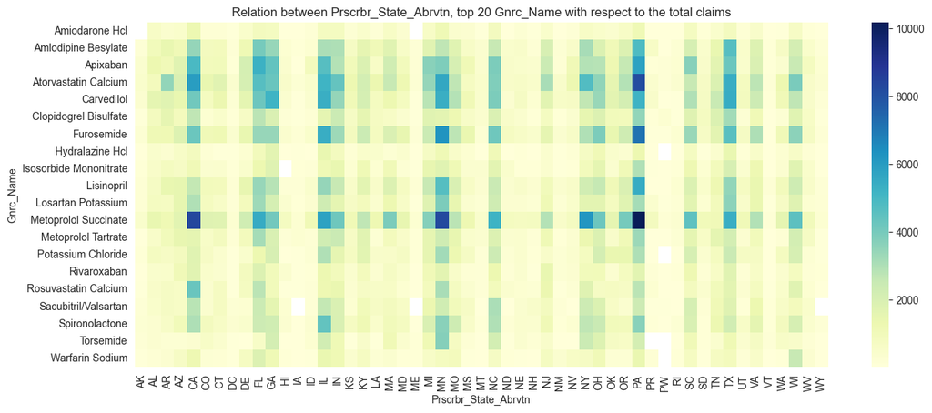

In this chart we got the top 20 generic drug names in total claims and then we are showing the relation of this drugs to each state. we can gain insight about the states that need specific drugs more than the others through our heatmap , the heat bar represents the total claims of the drug.